# Zaliczenie przedmiotu ‘Machine Learning’

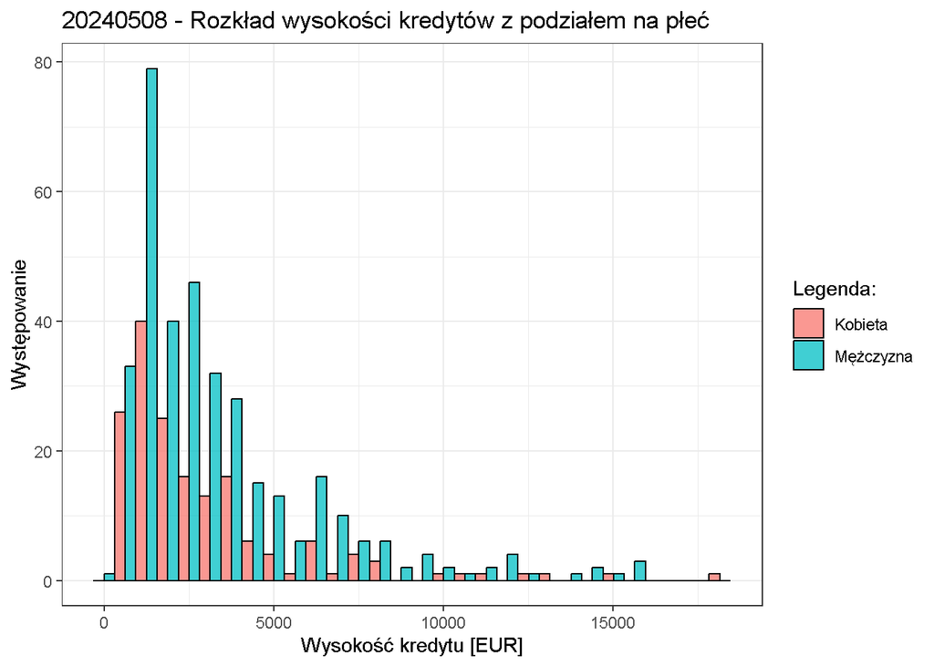

```r
### Wysokość kredytu - z podziałem na płeć:
df_dane %>%
  ggplot() +
  geom_histogram(aes(x = Wysokość_kredytu, fill = Płeć),
                 alpha = 0.75, position = "dodge",
                 colour = "black") +
  theme_bw() +
  labs(title = "20240508 - Rozkład wysokości kredytów z podziałem na płeć",
       x = "Wysokość kredytu [EUR]", y = "Występowanie", fill="Legenda:")
```

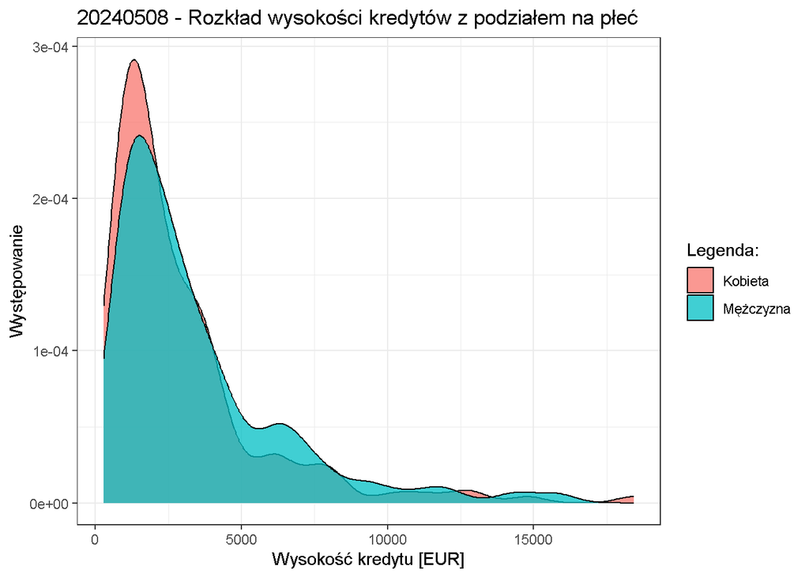

```r
df_dane %>%
  ggplot() +
  geom_density(aes(x = Wysokość_kredytu, fill = Płeć),
               alpha = 0.75,
               colour = "black") +
  theme_bw() +
  labs(title = "20240508 - Rozkład wysokości kredytów z podziałem na płeć",
       x = "Wysokość kredytu [EUR]", y = "Występowanie", fill="Legenda:")
```

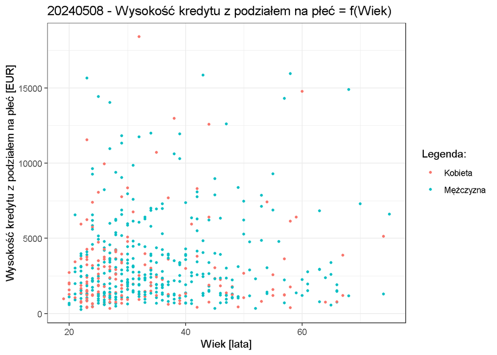

```r
df_dane %>%
  ggplot() +
  geom_point(aes(x = Wiek, y = Wysokość_kredytu, col = Płeć),
             size = integer_rozmiar_punktu_danych_na_wykresach) +
  theme_bw() +
  labs(title = "20240508 - Wysokość kredytu z podziałem na płeć = f(Wiek)",
       x = "Wiek [lata]", y = "Wysokość kredytu z podziałem na płeć [EUR]",
       col = "Legenda:")
```

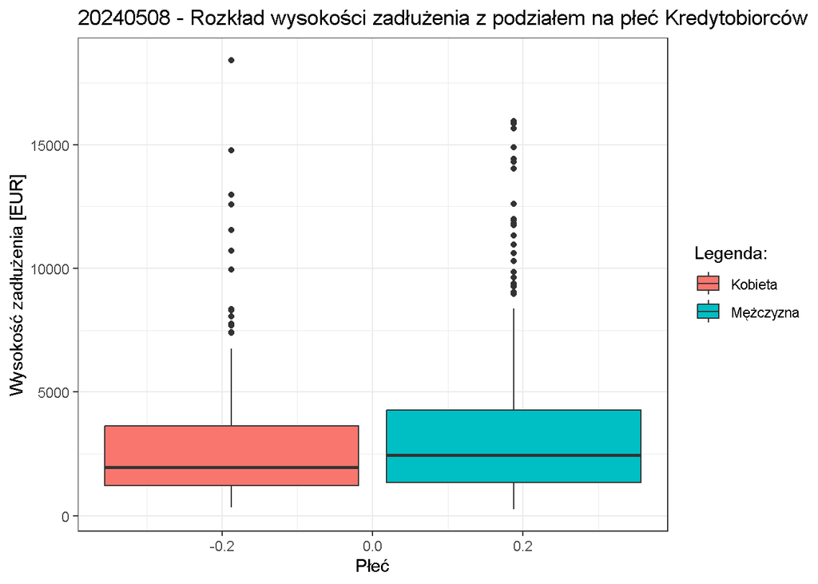

```r
df_dane %>%
  ggplot() +
  geom_boxplot(aes(y = Wysokość_kredytu, fill = Płeć)) +
  theme_bw() +
  labs(title = "20240508 - Rozkład wysokości zadłużenia z podziałem na płeć Kredytobiorców",
       x = "Płeć", y = "Wysokość zadłużenia [EUR]", fill = "Legenda:")
```

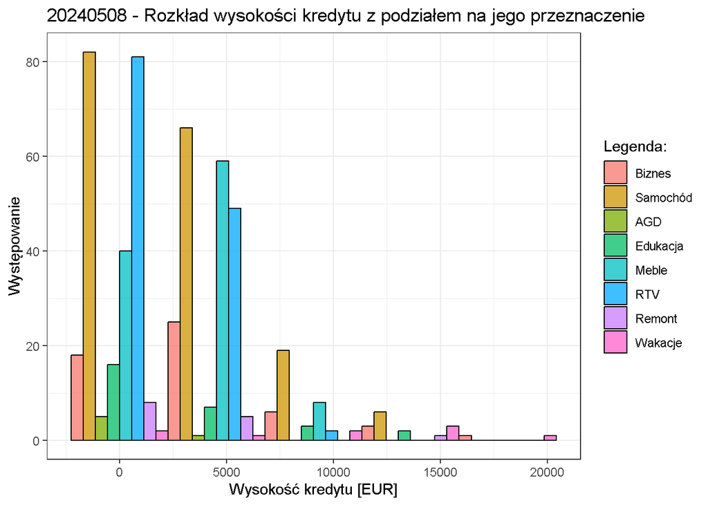

```r
### Wysokość kredytu, a jego przeznaczenie:
df_dane %>%
  ggplot() +
  geom_histogram(aes(x = Wysokość_kredytu, fill = Przeznaczenie_kredytu),
                 alpha = 0.75, position = "dodge",
                 colour = "black", bins = 5) +
  theme_bw() +
  labs(title = "20240508 - Rozkład wysokości kredytu z podziałem na jego przeznaczenie",
       x = "Wysokość kredytu [EUR]", y = "Występowanie", fill="Legenda:")
```

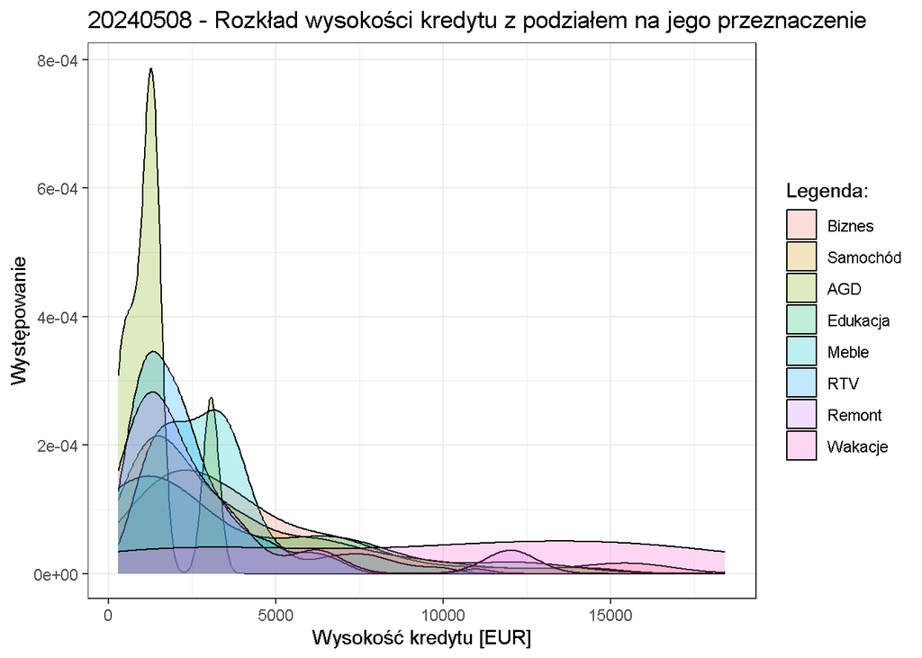

```r
df_dane %>%
  ggplot() +
  geom_density(aes(x = Wysokość_kredytu, fill = Przeznaczenie_kredytu),
               alpha = 0.25,
               colour = "black") +
  theme_bw() +
  labs(title = "20240508 - Rozkład wysokości kredytu z podziałem na jego przeznaczenie",
       x = "Wysokość kredytu [EUR]", y = "Występowanie", fill="Legenda:")
```

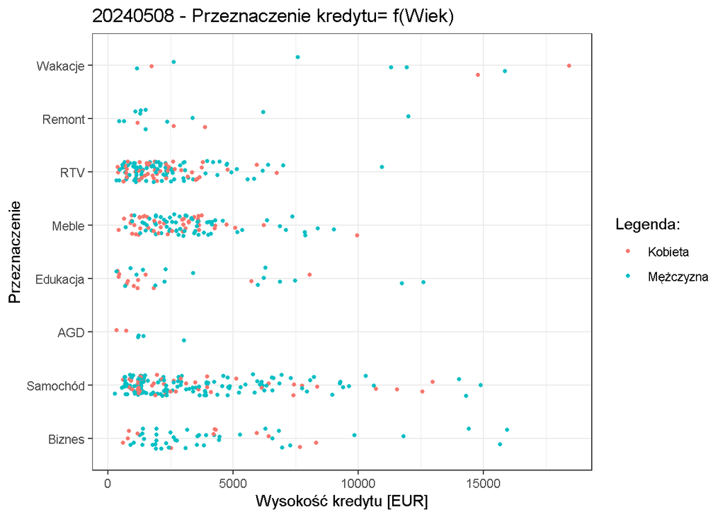

```r
df_dane %>%
  ggplot() +
  geom_jitter(aes(x = Wysokość_kredytu, y = Przeznaczenie_kredytu, col = Płeć),
              height = 0.2,
              size = integer_rozmiar_punktu_danych_na_wykresach) +
  theme_bw() +
  labs(title = "20240508 - Przeznaczenie kredytu= f(Wiek)",
       x = "Wysokość kredytu [EUR]", y = "Przeznaczenie", col = "Legenda:")
```

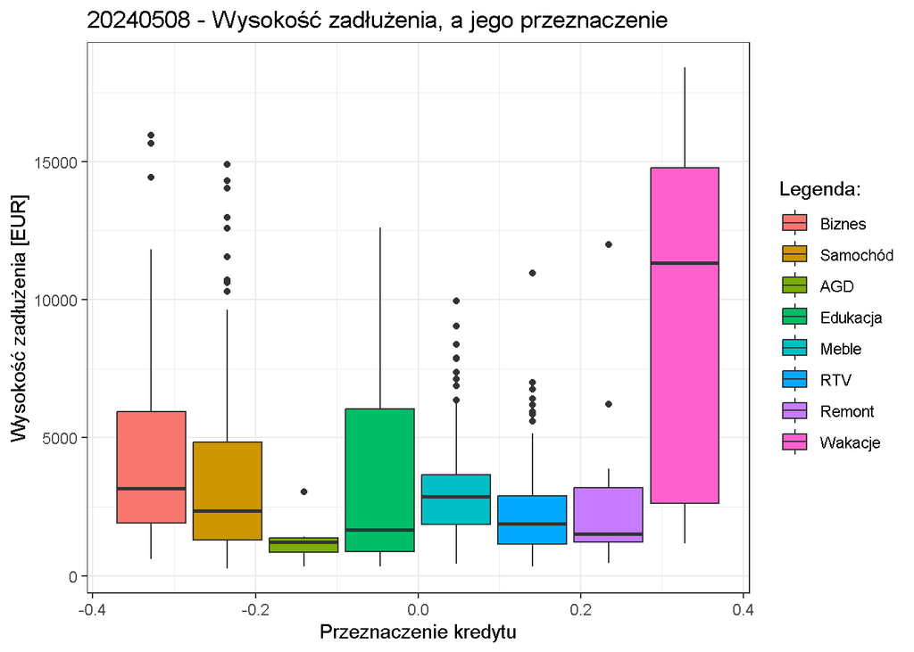

```r
df_dane %>%
  ggplot() +
  geom_boxplot(aes(y = Wysokość_kredytu, fill = Przeznaczenie_kredytu)) +
  theme_bw() +
  labs(title = "20240508 - Wysokość zadłużenia, a jego przeznaczenie",
       x = "Przeznaczenie kredytu", y = "Wysokość zadłużenia [EUR]", fill = "Legenda:")
```

### 2.3.7. Okres kredytowania

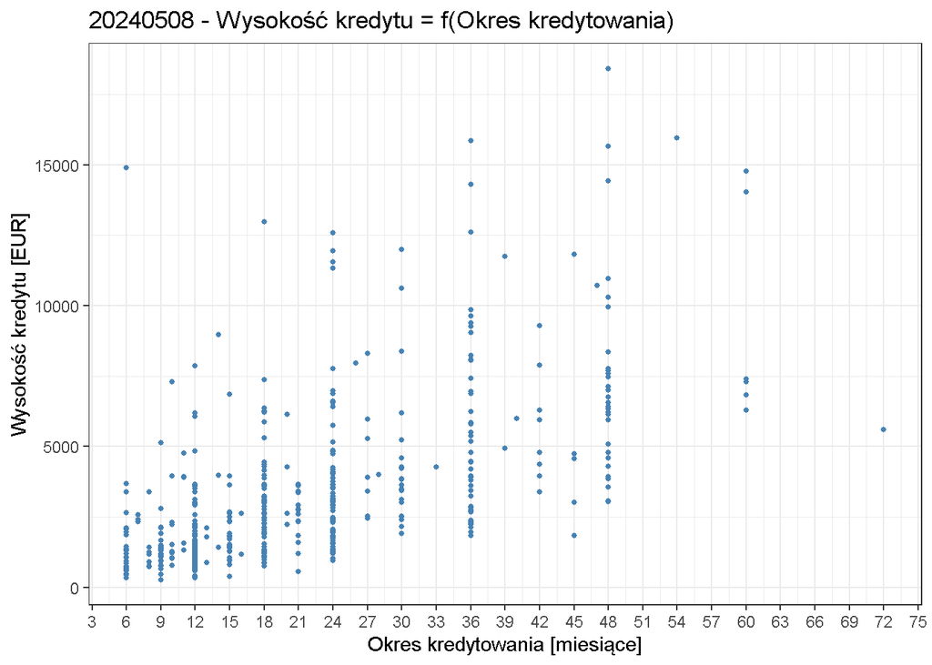

```r
df_dane %>%
  ggplot() +
  geom_point(aes(x = Okres_kredytowania, y = Wysokość_kredytu),
             color = string_kolor_punktu_danych_na_wykresach,
             size = integer_rozmiar_punktu_danych_na_wykresach) +
  theme_bw() +
  labs(title = "20240508 - Wysokość kredytu = f(Okres kredytowania)",
       x = "Okres kredytowania [miesiące]", y = "Wysokość kredytu [EUR]") +
  scale_x_continuous(breaks=seq(3, 78, by=3))
```

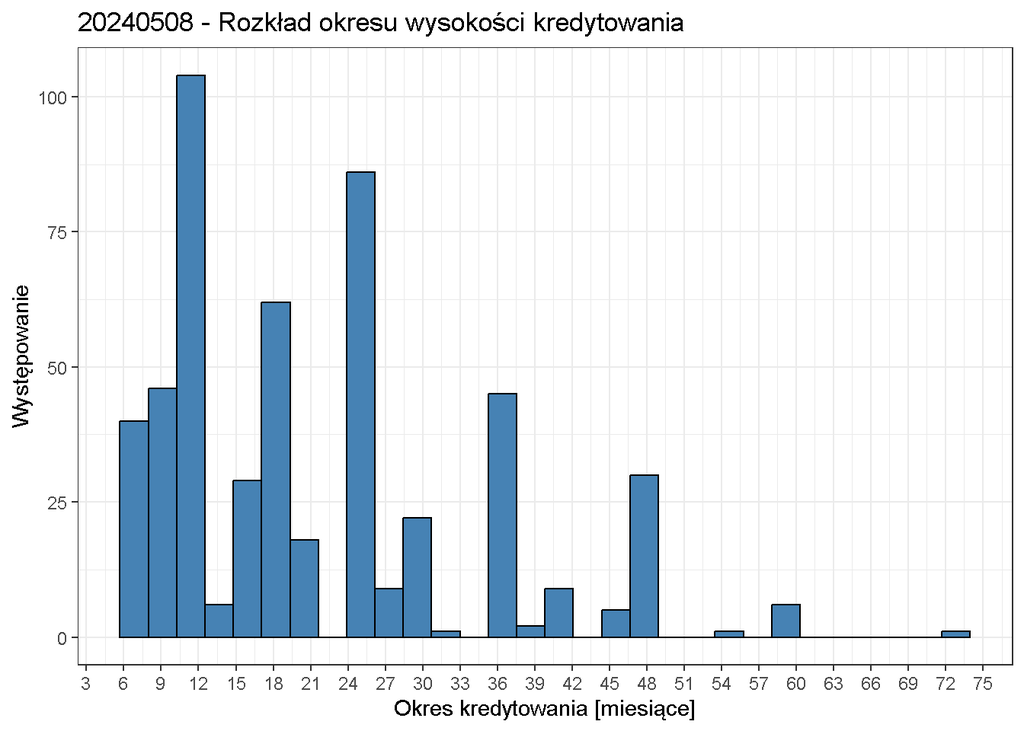

```r
df_dane %>%
  ggplot() +
  geom_histogram(aes(x = Okres_kredytowania),
                 fill = "steelblue",
                 color = "black") +
  theme_bw() +
  labs(title = "20240508 - Rozkład okresu wysokości kredytowania",
       x = "Okres kredytowania [miesiące]", y = "Występowanie") +
  scale_x_continuous(breaks=seq(3, 78, by=3))
```

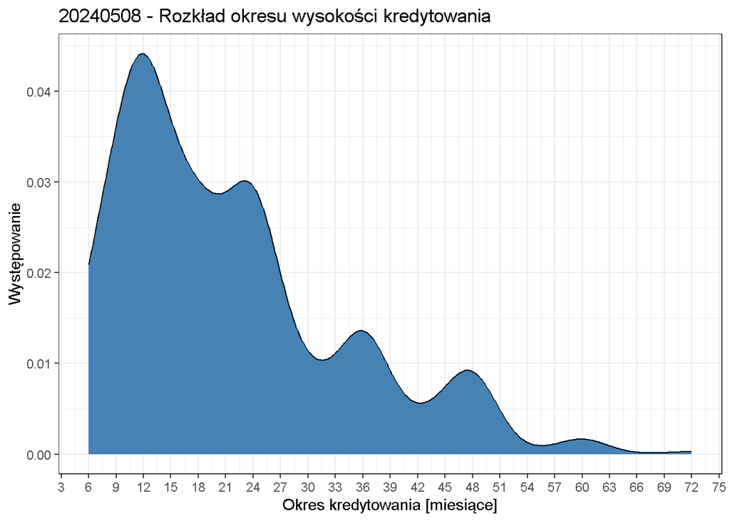

```r
df_dane %>%
  ggplot() +
  geom_density(aes(x = Okres_kredytowania),
               fill = "steelblue",
               color = "black") +
  theme_bw() +
  labs(title = "20240508 - Rozkład okresu wysokości kredytowania",
       x = "Okres kredytowania [miesiące]", y = "Występowanie") +
  scale_x_continuous(breaks=seq(3, 78, by=3))
```

### 2.3.8. Przeznaczenie kredytu

```r
wektor_przeznaczenie_kredytu_w_badanej_probie <- table(df_dane$Przeznaczenie_kredytu)
names(wektor_przeznaczenie_kredytu_w_badanej_probie) <- c("Biznes [Liczba]",
                                                          "Samochód [Liczba]",
                                                          "AGD [Liczba]",
                                                          "Edukacja [Liczba]",
                                                          "Meble [Liczba]",
                                                          "RTV [Liczba]",
                                                          "Remont [Liczba]",
                                                          "Wakacje [Liczba]")

wektor_przeznaczenie_kredytu_w_badanej_probie_procenty <-
  funkcja_konwersja_wartosci_wektora_na_procenty(wektor_przeznaczenie_kredytu_w_badanej_probie,1)
names(wektor_przeznaczenie_kredytu_w_badanej_probie_procenty) <- c("Biznes [%]",
                                                                   "Samochód [%]",
                                                                   "AGD [%]",
                                                                   "Edukacja [%]",
                                                                   "Meble [%]",
                                                                   "RTV [%]",
                                                                   "Remont [%]",
                                                                   "Wakacje [%]")
wektor_przeznaczenie_kredytu_w_badanej_probie
```

```
##   Biznes [Liczba] Samochód [Liczba]      AGD [Liczba] Edukacja [Liczba]
##                53               173                 6                28
##    Meble [Liczba]      RTV [Liczba]   Remont [Liczba]  Wakacje [Liczba]
##               107               132                14                 9
```

```r
wektor_przeznaczenie_kredytu_w_badanej_probie_procenty
```

```
##   Biznes [%] Samochód [%]      AGD [%] Edukacja [%]    Meble [%]      RTV [%]
##         10.2         33.1          1.1          5.4         20.5         25.3
##   Remont [%]  Wakacje [%]
##          2.7          1.7
```

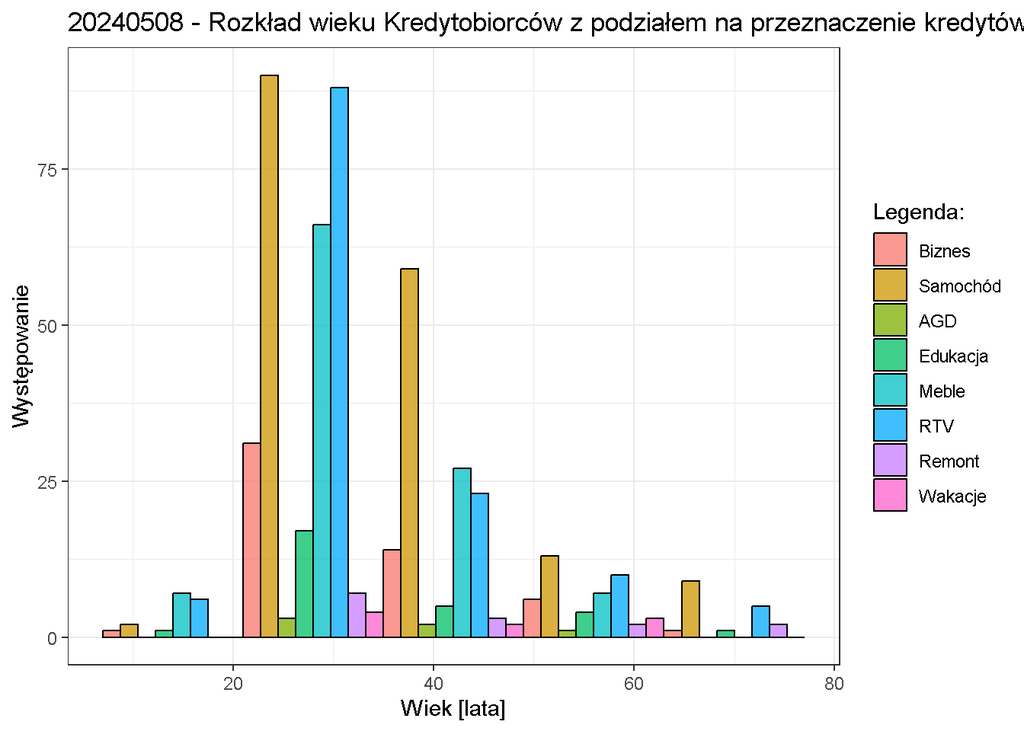

```r
df_dane %>%
  ggplot() +
  geom_histogram(aes(x = Wiek, fill = Przeznaczenie_kredytu),
                 alpha = 0.75, position = "dodge",
                 colour = "black", bins = 5) +
  theme_bw() +
  labs(title = "20240508 - Rozkład wieku Kredytobiorców z podziałem na przeznaczenie kredytów",
       x = "Wiek [lata]", y = "Występowanie", fill="Legenda:")
```

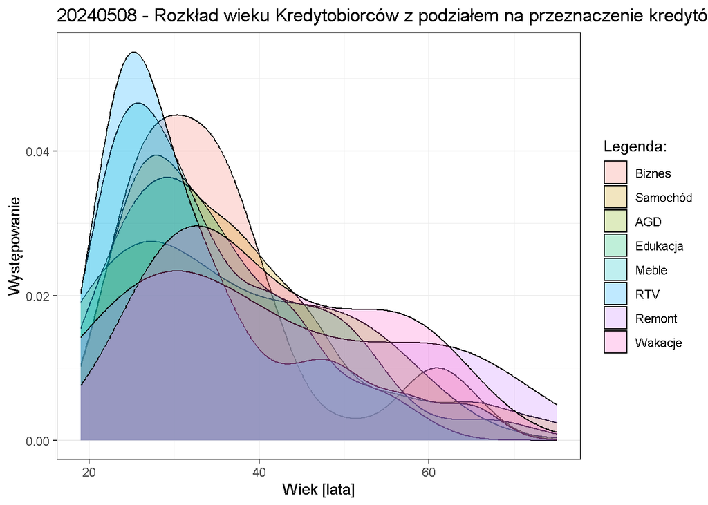

```r
df_dane %>%
  ggplot() +
  geom_density(aes(x = Wiek, fill = Przeznaczenie_kredytu),
                 alpha = 0.25,
                 colour = "black") +
  theme_bw() +
  labs(title = "20240508 - Rozkład wieku Kredytobiorców z podziałem na przeznaczenie kredytów",
       x = "Wiek [lata]", y = "Występowanie", fill="Legenda:")
```

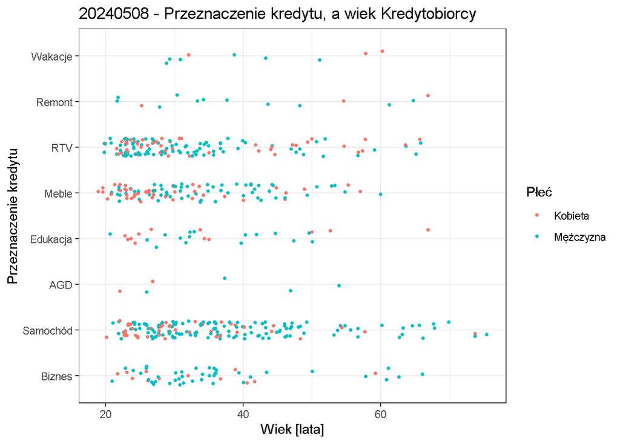

```r
df_dane %>%
  ggplot() +
  geom_jitter(aes(x = Wiek, y = Przeznaczenie_kredytu, col = Płeć),
              height = 0.2,
              size = integer_rozmiar_punktu_danych_na_wykresach) +
  theme_bw() +
  labs(title = "20240508 - Przeznaczenie kredytu, a wiek Kredytobiorcy",
       x = "Wiek [lata]", y = "Przeznaczenie kredytu", fill="Legenda:")
```

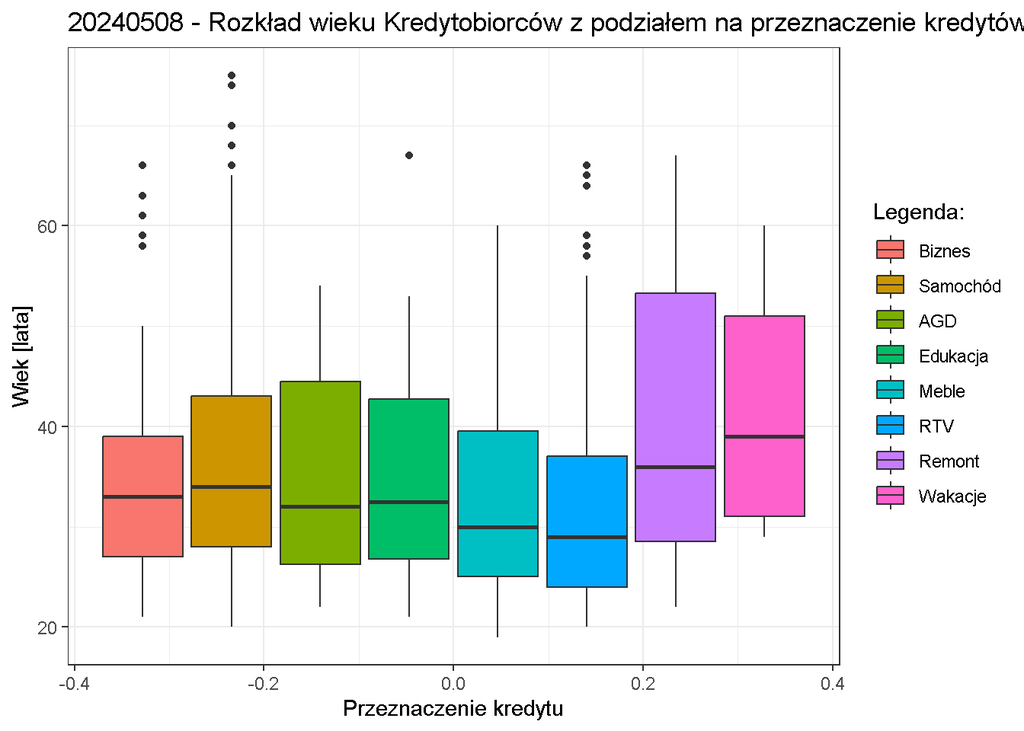

```r
df_dane %>%
  ggplot() +
  geom_boxplot(aes(y = Wiek, fill = Przeznaczenie_kredytu)) +
  theme_bw() +
  labs(title = "20240508 - Rozkład wieku Kredytobiorców z podziałem na przeznaczenie kredytów", y = "Wiek [lata]", x = "Przeznaczenie kredytu", fill="Legenda:")
```

## 2.4. Podsumowanie EDA

Niniejsza sekcja zawiera podsumowanie oraz wnioski Eksploracyjnej Analizy Danych (EDA). Na podstawie przeprowadzonej EDA podjęta zostanie decyzja dot. wyboru zmiennej objaśnianej (Y) oraz objaśniających (X1, X2, X3, …).

W dalszej kolejności, wybrane zmienne posłużą budowie modeli regresyjnych przy użyciu technik uczenia maszynowego (ML).

### 2.4.1. Obserwacje i wnioski

Po wstępnej obróbce danych, w badanej próbie 67.8% niemieckich Kredytobiorców jest płci męskiej, a 32.2% to Kobiety.

Wśród kredytobiorców, 75% procent (trzeci kwartyl) stanowią ludzie poniżej 40. roku życia, mediana wieku Kredytobiorców to 31.5 roku. Mężczyźni biorą kredyty później od Kobiet: 33 lata (mediana dla meżczyzn) oraz 28.5 lat (mediana dla Kobiet).

Najem i mieszkania własnościowe stanowią ponad połowę typów nieruchomości, w których żyją niemieccy Kredytobiorcy dla danej próby. Mieszkania socjalne są najmniej popularne (mniej niż połowa). Wśród młodych ludzi (< 30 lat) dominuje najem (1. pozycja) oraz mieszkania własnościowe (2. pozycja). Mediana wieku wszystkich wynajmujących to 27 lat, a mediana wieku właścicieli mieszkań to 30 lat. Wśród osób wynajmujących mieszkania, połowa (kwartyle 1. oraz 3.) to osoby w wieku od 25 do 35 lat. Wśród osób posiadających mieszkania na własność, widzimy szerszy przekrój wieku badanych: od 27. do 40. roku życia (kwartyle 1. oraz 3.). Ludzie od 35. do 55. roku życia żyją raczej w mieszkaniach socjalnych - mediana wieku zamieszkujących mieszkania socjalne to 45 lat, a pierwszy i trzeci kwartyl dla tej grupy społecznej mają wartości odpowiednio 35 oraz 55 lat.

Bez względu na rodzaj posiadanej nieruchomości (najem, własnościowe, socjalne), wszystkie grupy społeczne w badanej próbie mają niskie oszczędności (oceniono na podstawie zmiennych jakościowych). Mężczyźni w grupie posiadaczy mieszkań mają zauważalnie wyższe oszczędności niż Kobiety (oceniono na podstawie zmiennych jakościowych).

Co ciekawe, bez względu na rodzaj posiadanej nieruchomości (najem, własnościowe, socjalne), wszystkie grupy społeczne mają również niskie zadłużenie (oceniono na podstawie zmiennych jakościowych). Najniższe zadłużenie cechuje najemców - kwartyl pierwszy i trzeci zadłużenia wynoszą: 2000EUR i 3000EUR, a mediana to 2500EUR. Osoby w mieszkaniach socjalnych są najbardziej zadłużone - kwartyl pierwszy i trzeci zadłużenia wynoszą w tym przypadku: 4000EUR i 7500EUR, a mediana to 4250EUR.  
Pod względem wysokości zadłużenia, najwięcej osób zadłużonych na sumy powyżej 7500EUR jest w grupie właścicieli mieszkań, a w dalszej kolejności wśród najemców. Osoby w mieszkaniach socjalnych są najczęściej zadłużone. Najemcy oraz posiadacze mieszkań zadłużają się rzadziej, lecz na wyższe sumy.

Wysokość oszczędności jest praktycznie niezależna od wieku Kredytobiorcy, a przytłaczająca większość badanych (78.9%) ma niskie oszczędności (oceniono na podstawie zmiennych jakościowych). Niskie lub umiarkowane oszczędności ma łącznie aż 91.2% niemieckich Kredytobiorców w badanej próbie.

Powyższe informacje na temat stanu oszczędności Kredytobiorców potwierdzają wyniki sald rachunków bieżących: 89,8% ma saldo niskie lub umiarkowane (oceniono na podstawie zmiennych jakościowych).

Krótki okres kredytowania (do 48 miesięcy) oraz fakt, że kredyty są głównie przeznaczane na bieżącą konsumpcję sugeruje, iż analizowana baza danych zawiera dane kredytów konsumenckich.

### 2.4.2. Koncepcja modelu

Wytrenowany zostanie model zależności płci kredytobiorców (zmienna objaśniana - Y) od pozostałych zmiennych objaśniających (X).

Na podstawie przeprowadzonej analizy EDA wyróżnić można następujące zależności zmiennych Y=f(X), z podziałem na dwie grupy pod względem mocy dyskryminacyjnej, [1]:

- Duża moc dyskyminacyjna:
  - Płeć = f(Wiek)
  - Płeć = f(Przeznaczenie kredytu)
  - Płeć = f(Nieruchomości)
- Niska moc dyskyminacyjna:
  - Płeć = f(Zatrudnienie)
  - Płeć = f(Oszczędności)
  - Płeć = f(Saldo bieżące)
  - Płeć = f(Okres kredytowania)
  - Płeć = f(Wysokość kredytu)

Tym samym, w kolejnym rozdziale zbudowane zostaną dwa modele uczenia maszynowego: jeden tylko dla zmiennych o dużej mocy dyskryminacyjnej i jeden dla zmiennych o zróżnicowanych mocach (wszystkie ww. zmienne objaśniające).

# 3. Modele ML

W niniejszym rozdziale wytrenowane oraz przetestowane zostaną modele uczenia maszynowego (ang. machine learning; skrót: ML).

Modele ML zostaną zbudowane z wykorzystaniem następujących technik:

- metoda kNN
- metoda drzew decyzyjnych
- metoda “random forest”

W toku pracy optymalizowane będą wartości wybranych hiperparametrów modeli.

## 3.1. Wstępna konfiguracja

```r
### Ziarno dla wszystkich modeli:
set.seed(123)

### Konfiguracja kroswalidacji danych:
obiekt_kroswalidacji_danych <- trainControl(method = "repeatedcv",
                                            number = 5,
                                            repeats = 3)

### Budowa macierzy wynikowej ACSS:
macierz_podsumowania = matrix(c(1:18), ncol=3, byrow=TRUE)
colnames(macierz_podsumowania) <- c('Accuracy','Sensitivity','Specifity')
rownames(macierz_podsumowania) <- c("Zestaw 3X | Model kNN",
                                    "Zestaw 3X | Model drzew decyzyjnych",
                                    "Zestaw 3X | Model 'Random Forest'",
                                    "Zestaw 7X | Model kNN",
                                    "Zestaw 7X | Model drzew decyzyjnych",
                                    "Zestaw 7X | Model 'Random Forest'")
macierz_podsumowania <- as.table(macierz_podsumowania)
```

## 3.2. Modele ML dla 3X

W niniejszej sekcji wytrenowano modele uczenia maszynowego ML dla zestawu danych z trzema zmiennymi objaśniającymi.

### 3.2.1. Przygotowanie danych

```r
### Przygotowanie danych - pozostawiam tylko zmienne:
# - Y - objaśnianą:
#   - "Płeć"
# - X - objasniające:
#   - "Wiek"
#   - "Nieruchomości"
#   - "Przeznaczenie_kredytu"

wektor_zachowaj_kolumny <- c("Płeć",
                             "Wiek",
                             "Nieruchomości",
                             "Przeznaczenie_kredytu")

df_dane_3_zmienne_objasniajace <- subset(df_dane, select = wektor_zachowaj_kolumny)

### Podział danych na uczące i testowe:
wektor_podzial_danych_uczacych <- createDataPartition(
  df_dane_3_zmienne_objasniajace$Płeć,
  p = 0.7,
  list = FALSE)

df_dane_uczace_3_zmienne_objasniajace <-
  df_dane_3_zmienne_objasniajace[wektor_podzial_danych_uczacych,]
df_dane_testowe_3_zmienne_objasniajace <-
  df_dane_3_zmienne_objasniajace[-wektor_podzial_danych_uczacych,]
```

### 3.2.2. Model kNN

```r
### Budowa modelu wraz z optymalizacją hiperparametrów:
obiekt_modelu_kNN_3_zmienne_objasniajace <-
  train(Płeć ~.,
        data = df_dane_uczace_3_zmienne_objasniajace,
        method = "knn",
        preProc = c("center", "scale"),
        trControl = obiekt_kroswalidacji_danych,
        tuneGrid = data.frame(k = c(5:11))
        )

### Prognoza:
prognoza_modelu_kNN_3_zmienne_objasniajace <-
  predict(obiekt_modelu_kNN_3_zmienne_objasniajace,
          df_dane_testowe_3_zmienne_objasniajace)

### Macierz pomyłek:
macierz_pomylek_modelu_kNN_3_zmienne_objasniajace <-
  confusionMatrix(prognoza_modelu_kNN_3_zmienne_objasniajace,
                  df_dane_testowe_3_zmienne_objasniajace$Płeć)

### Podsumowanie i podział wyników:
tabela_wynikow_modelu_kNN_3_zmienne_objasniajace <-
  macierz_pomylek_modelu_kNN_3_zmienne_objasniajace[2]
float_accuracy_modelu_kNN_3_zmienne_objasniajace <-
  macierz_pomylek_modelu_kNN_3_zmienne_objasniajace[3]$overall[1]
float_accuracy_modelu_kNN_3_zmienne_objasniajace
```

```
##  Accuracy
## 0.7179487
```

```r
float_senstivity_modelu_kNN_3_zmienne_objasniajace <-
  macierz_pomylek_modelu_kNN_3_zmienne_objasniajace[4]$byClass[1]
float_specificity_modelu_kNN_3_zmienne_objasniajace <-
  macierz_pomylek_modelu_kNN_3_zmienne_objasniajace[4]$byClass[2]

### Przypisanie wyników do macierzy podsumowania:
macierz_podsumowania[1,1] <- float_accuracy_modelu_kNN_3_zmienne_objasniajace
macierz_podsumowania[1,2] <- float_senstivity_modelu_kNN_3_zmienne_objasniajace
macierz_podsumowania[1,3] <- float_specificity_modelu_kNN_3_zmienne_objasniajace
```

### 3.2.3. Model drzew decyzyjnych

```r
### Budowa modelu wraz z optymalizacją hiperparametrów:
obiekt_modelu_drzew_decyzyjnych_3_zmienne_objasniajace <-
  train(Płeć ~.,
  data = df_dane_uczace_3_zmienne_objasniajace,
  method = "rpart",
  preProc = c("center", "scale"),
  trControl = obiekt_kroswalidacji_danych,
  tuneLength = 5)

### Prognoza:
prognoza_modelu_drzew_decyzyjnych_3_zmienne_objasniajace <-
  predict(obiekt_modelu_drzew_decyzyjnych_3_zmienne_objasniajace,
          df_dane_testowe_3_zmienne_objasniajace)

### Macierz pomyłek:
macierz_pomylek_modelu_drzew_decyzyjnych_3_zmienne_objasniajace <-
  confusionMatrix(
    prognoza_modelu_drzew_decyzyjnych_3_zmienne_objasniajace,
    df_dane_testowe_3_zmienne_objasniajace$Płeć)

### Podsumowanie i podział wyników:
tabela_wynikow_modelu_drzew_decyzyjnych_3_zmienne_objasniajace <-
  macierz_pomylek_modelu_drzew_decyzyjnych_3_zmienne_objasniajace[2]
float_accuracy_modelu_drzew_decyzyjnych_3_zmienne_objasniajace <-
  macierz_pomylek_modelu_drzew_decyzyjnych_3_zmienne_objasniajace[3]$overall[1]
float_senstivity_modelu_drzew_decyzyjnych_3_zmienne_objasniajace <-
  macierz_pomylek_modelu_drzew_decyzyjnych_3_zmienne_objasniajace[4]$byClass[1]
float_specificity_modelu_drzew_decyzyjnych_3_zmienne_objasniajace <-
  macierz_pomylek_modelu_drzew_decyzyjnych_3_zmienne_objasniajace[4]$byClass[2]

### Przypisanie wyników do macierzy podsumowania:
macierz_podsumowania[2,1] <- float_accuracy_modelu_drzew_decyzyjnych_3_zmienne_objasniajace
macierz_podsumowania[2,2] <- float_senstivity_modelu_drzew_decyzyjnych_3_zmienne_objasniajace
macierz_podsumowania[2,3] <- float_specificity_modelu_drzew_decyzyjnych_3_zmienne_objasniajace
```

### 3.2.4. Model “random forest”

```r
### Budowa modelu wraz z optymalizacją hiperparametrów:
obiekt_modelu_random_forest_3_zmienne_objasniajace <-
  train(Płeć ~.,
  data = df_dane_uczace_3_zmienne_objasniajace,
  method = "rf",
  preProc = c("center", "scale"),
  trControl = obiekt_kroswalidacji_danych,
  tuneLength = 5)

### Prognoza:
prognoza_modelu_random_forest_3_zmienne_objasniajace <-
  predict(obiekt_modelu_random_forest_3_zmienne_objasniajace,
          df_dane_testowe_3_zmienne_objasniajace)

### Macierz pomyłek:
macierz_pomylek_modelu_random_forest_3_zmienne_objasniajace <-
  confusionMatrix(
    prognoza_modelu_random_forest_3_zmienne_objasniajace,
    df_dane_testowe_3_zmienne_objasniajace$Płeć)

### Podsumowanie i podział wyników:
tabela_wynikow_modelu_random_forest_3_zmienne_objasniajace <-
  macierz_pomylek_modelu_random_forest_3_zmienne_objasniajace[2]
float_accuracy_modelu_random_forest_3_zmienne_objasniajace <-
  macierz_pomylek_modelu_random_forest_3_zmienne_objasniajace[3]$overall[1]
float_senstivity_modelu_random_forest_3_zmienne_objasniajace <-
  macierz_pomylek_modelu_random_forest_3_zmienne_objasniajace[4]$byClass[1]
float_specificity_modelu_random_forest_3_zmienne_objasniajace <-
  macierz_pomylek_modelu_random_forest_3_zmienne_objasniajace[4]$byClass[2]

### Przypisanie wyników do macierzy podsumowania:
macierz_podsumowania[3,1] <- float_accuracy_modelu_random_forest_3_zmienne_objasniajace
macierz_podsumowania[3,2] <- float_senstivity_modelu_random_forest_3_zmienne_objasniajace
macierz_podsumowania[3,3] <- float_specificity_modelu_random_forest_3_zmienne_objasniajace
```

## 3.3. Modele ML dla 7X

### 3.3.1. Przygotowanie danych

```r
### Przygotowanie danych - pozostawiam tylko zmienne:
# - Y - objaśnianą:
#   - "Płeć"
# - X - objasniające:
#   - "Wiek"
#   - "Zatrudnienie"
#   - "Nieruchomości"
#   - "Rachunek_oszczędnościowy "
#   - "Rachunek_bieżący"
#   - "Przeznaczenie_kredytu"
#   - "Okres_kredytowania"
#   - "Wysokość_kredytu"

wektor_zachowaj_kolumny <- c("Płeć",
                             "Wiek",
                             "Zatrudnienie",
                             "Nieruchomości",
                             "Rachunek_oszczędnościowy",
                             "Rachunek_bieżący",
                             "Przeznaczenie_kredytu",
                             "Okres_kredytowania",
                             "Wysokość_kredytu")

df_dane_7_zmiennych_objasniajacych <- subset(df_dane, select = wektor_zachowaj_kolumny)

### Podział danych na uczące i testowe:
wektor_podzial_danych_uczacych <- createDataPartition(
  df_dane_7_zmiennych_objasniajacych$Płeć,
  p = 0.7,
  list = FALSE)

df_dane_uczace_7_zmiennych_objasniajacych <-
  df_dane_7_zmiennych_objasniajacych[wektor_podzial_danych_uczacych,]
df_dane_testowe_7_zmiennych_objasniajacych <-
  df_dane_7_zmiennych_objasniajacych[-wektor_podzial_danych_uczacych,]
```

### 3.3.2. Model kNN

```r
### Budowa modelu wraz z optymalizacją hiperparametrów:
obiekt_modelu_kNN_7_zmiennych_objasniajacych <-
  train(Płeć ~.,
        data = df_dane_uczace_7_zmiennych_objasniajacych,
        method = "knn",
        preProc = c("center", "scale"),
        trControl = obiekt_kroswalidacji_danych,
        tuneGrid = data.frame(k = c(5:11))
  )

### Prognoza:
prognoza_modelu_kNN_7_zmiennych_objasniajacych <-
  predict(obiekt_modelu_kNN_7_zmiennych_objasniajacych,
          df_dane_testowe_7_zmiennych_objasniajacych)

### Macierz pomyłek:
macierz_pomylek_modelu_kNN_7_zmiennych_objasniajacych <-
  confusionMatrix(prognoza_modelu_kNN_7_zmiennych_objasniajacych,
                  df_dane_testowe_7_zmiennych_objasniajacych$Płeć)

### Podsumowanie i podział wyników:
tabela_wynikow_modelu_kNN_7_zmiennych_objasniajacych <-
  macierz_pomylek_modelu_kNN_7_zmiennych_objasniajacych[2]
float_accuracy_modelu_kNN_7_zmiennych_objasniajacych <-
  macierz_pomylek_modelu_kNN_7_zmiennych_objasniajacych[3]$overall[1]
float_senstivity_modelu_kNN_7_zmiennych_objasniajacych <-
  macierz_pomylek_modelu_kNN_7_zmiennych_objasniajacych[4]$byClass[1]
float_specificity_modelu_kNN_7_zmiennych_objasniajacych <-
  macierz_pomylek_modelu_kNN_7_zmiennych_objasniajacych[4]$byClass[2]

### Przypisanie wyników do macierzy podsumowania:
macierz_podsumowania[4,1] <- float_accuracy_modelu_kNN_7_zmiennych_objasniajacych
macierz_podsumowania[4,2] <- float_senstivity_modelu_kNN_7_zmiennych_objasniajacych
macierz_podsumowania[4,3] <-float_specificity_modelu_kNN_7_zmiennych_objasniajacych
```

### 3.3.3. Model drzew decyzyjnych

```r
### Budowa modelu wraz z optymalizacją hiperparametrów:
obiekt_modelu_drzew_decyzyjnych_7_zmiennych_objasniajacych <-
  train(Płeć ~.,
        data = df_dane_uczace_7_zmiennych_objasniajacych,
        method = "rpart",
        preProc = c("center", "scale"),
        trControl = obiekt_kroswalidacji_danych,
        tuneLength = 5)

### Prognoza:
prognoza_modelu_drzew_decyzyjnych_7_zmiennych_objasniajacych <-
  predict(obiekt_modelu_drzew_decyzyjnych_7_zmiennych_objasniajacych,
          df_dane_testowe_7_zmiennych_objasniajacych)

### Macierz pomyłek:
macierz_pomylek_modelu_drzew_decyzyjnych_7_zmiennych_objasniajacych <-
  confusionMatrix(
    prognoza_modelu_drzew_decyzyjnych_7_zmiennych_objasniajacych,
    df_dane_testowe_7_zmiennych_objasniajacych$Płeć)

### Podsumowanie i podział wyników:
tabela_wynikow_modelu_drzew_decyzyjnych_7_zmiennych_objasniajacych <-
  macierz_pomylek_modelu_drzew_decyzyjnych_7_zmiennych_objasniajacych[2]
float_accuracy_modelu_drzew_decyzyjnych_7_zmiennych_objasniajacych <-
  macierz_pomylek_modelu_drzew_decyzyjnych_7_zmiennych_objasniajacych[3]$overall[1]
float_senstivity_modelu_drzew_decyzyjnych_7_zmiennych_objasniajacych <-
  macierz_pomylek_modelu_drzew_decyzyjnych_7_zmiennych_objasniajacych[4]$byClass[1]
float_specificity_modelu_drzew_decyzyjnych_7_zmiennych_objasniajacych <-
  macierz_pomylek_modelu_drzew_decyzyjnych_7_zmiennych_objasniajacych[4]$byClass[2]

### Przypisanie wyników do macierzy podsumowania:
macierz_podsumowania[5,1] <- float_accuracy_modelu_drzew_decyzyjnych_7_zmiennych_objasniajacych
macierz_podsumowania[5,2] <- float_senstivity_modelu_drzew_decyzyjnych_7_zmiennych_objasniajacych
macierz_podsumowania[5,3] <- float_specificity_modelu_drzew_decyzyjnych_7_zmiennych_objasniajacych
```

### 3.3.4. Model “random forest”

```r
### Budowa modelu wraz z optymalizacją hiperparametrów:
obiekt_modelu_random_forest_7_zmiennych_objasniajacych <-
  train(Płeć ~.,
        data = df_dane_uczace_7_zmiennych_objasniajacych,
        method = "rf",
        preProc = c("center", "scale"),
        trControl = obiekt_kroswalidacji_danych,
        tuneLength = 5)

### Prognoza:
prognoza_modelu_random_forest_7_zmiennych_objasniajacych <-
  predict(obiekt_modelu_random_forest_7_zmiennych_objasniajacych,
          df_dane_testowe_7_zmiennych_objasniajacych)

### Macierz pomyłek:
macierz_pomylek_modelu_random_forest_7_zmiennych_objasniajacych <-
  confusionMatrix(
    prognoza_modelu_random_forest_7_zmiennych_objasniajacych,
    df_dane_testowe_7_zmiennych_objasniajacych$Płeć)

### Podsumowanie i podział wyników:
tabela_wynikow_modelu_random_forest_7_zmiennych_objasniajacych <-
  macierz_pomylek_modelu_random_forest_7_zmiennych_objasniajacych[2]
float_accuracy_modelu_random_forest_7_zmiennych_objasniajacych <-
  macierz_pomylek_modelu_random_forest_7_zmiennych_objasniajacych[3]$overall[1]
float_senstivity_modelu_random_forest_7_zmiennych_objasniajacych <-
  macierz_pomylek_modelu_random_forest_7_zmiennych_objasniajacych[4]$byClass[1]
float_specificity_modelu_random_forest_7_zmiennych_objasniajacych <-
  macierz_pomylek_modelu_random_forest_7_zmiennych_objasniajacych[4]$byClass[2]

### Przypisanie wyników do macierzy podsumowania:
macierz_podsumowania[6,1] <-
  float_accuracy_modelu_random_forest_7_zmiennych_objasniajacych
macierz_podsumowania[6,2] <- float_senstivity_modelu_random_forest_7_zmiennych_objasniajacych
macierz_podsumowania[6,3] <- float_specificity_modelu_random_forest_7_zmiennych_objasniajacych
```

# 4. Podsumowanie

## 4.1. Tabele prognoz

Poniżej przedstawiono tabele danych prognozowanych vs. dane testowe dla wszystkich trzech modeli (kNN, drzewa decyzyjne oraz “random forest”) wytrenowanych z wykorzystaniem dwóch różnych zestawów danych wejściowych (trzy zmienne objaśniające lub siedem zmiennych objaśniających).

Wyniki pogrupowano względem typów modeli ML celem umożliwienia porównania różnic między dwoma zestawami danych wejściowych.

Model kNN:

```r
# Zestaw danych: 3X
tabela_wynikow_modelu_kNN_3_zmienne_objasniajace
```

```
## $table
##            Reference
## Prediction  Kobieta Mężczyzna
##   Kobieta        14         8
##   Mężczyzna      36        98
```

```r
# Zestaw danych: 7X
tabela_wynikow_modelu_kNN_7_zmiennych_objasniajacych
```

```
## $table
##            Reference
## Prediction  Kobieta Mężczyzna
##   Kobieta         7         5
##   Mężczyzna      43       101
```

Model drzew decyzyjnych:

```r
### Zestaw danych: 3X
tabela_wynikow_modelu_drzew_decyzyjnych_3_zmienne_objasniajace
```

```
## $table
##            Reference
## Prediction  Kobieta Mężczyzna
##   Kobieta        12         2
##   Mężczyzna      38       104
```

```r
### Zestaw danych: 7X
tabela_wynikow_modelu_drzew_decyzyjnych_7_zmiennych_objasniajacych
```

```
## $table
##            Reference
## Prediction  Kobieta Mężczyzna
##   Kobieta        11         2
##   Mężczyzna      39       104
```

Model “random forest”:

```r
### Zestaw danych: 3X
tabela_wynikow_modelu_random_forest_3_zmienne_objasniajace
```

```
## $table
##            Reference
## Prediction  Kobieta Mężczyzna
##   Kobieta         4         1
##   Mężczyzna      46       105
```

```r
### Zestaw danych: 7X
tabela_wynikow_modelu_random_forest_7_zmiennych_objasniajacych
```

```
## $table
##            Reference
## Prediction  Kobieta Mężczyzna
##   Kobieta         7         1
##   Mężczyzna      43       105
```

## 4.2. Macierz podsumowania

Poniżej przedstawiono macierz podsumowania wybranych parametrów uczenia maszynowego.

W przeciwieństwie do punktu 4.1. tym razem wyniki pogrupowano względem liczby zmiennych objaśniających.

```r
macierz_podsumowania
```

```
##                                      Accuracy Sensitivity Specifity
## Zestaw 3X | Model kNN               0.7179487   0.2800000 0.9245283
## Zestaw 3X | Model drzew decyzyjnych 0.7435897   0.2400000 0.9811321
## Zestaw 3X | Model 'Random Forest'   0.6987179   0.0800000 0.9905660
## Zestaw 7X | Model kNN               0.6923077   0.1400000 0.9528302
## Zestaw 7X | Model drzew decyzyjnych 0.7371795   0.2200000 0.9811321
## Zestaw 7X | Model 'Random Forest'   0.7179487   0.1400000 0.9905660
```

## 4.3. Obserwacje i wnioski

Ogólna dokładność (“accuracy”) wszystkich trzech modeli jest do siebie zbliżona, ale jej wartość jest przeciętna i oscyluje w granicach 70-74%.

Jak widać na podstawie zestawienia tabel w sekcji 4.1. oraz wyników zebranych w macierzy sekcji 4.2. czułość (“sensitivity”) przewidywania płci Kobiet jest bardzo niska dla wszystkich trzech modeli. Być może jest to spowodowane faktem, iż Kobiety i mężczyźni są nierównomiernie reprezentowani w próbie - mężczyzni stanowią bowiem dwie trzecie próby.

W toku prac stwierdzono, że użycie wszystkich danych - włączając w to dane niepełne (N/A) - nie poprawiłoby w wymierny sposób jakości uczenia modeli.

# 5. Literatura

[1] - dr Jacek Wolak, wykład przedmiotu ``Machine Learning’’ studiów podyplomowych “Metody Statystycznej Analizy Danych - edycja IX”, Akademia Górniczo-Hutnicza w Krakowie, semestr letni 2024.